# Valuación de derivados

David R. Montalván Hernández

## **Instrumento derivado**

Un instrumento derivado es un contrato entre dos o más partes y cuyo valor se deriva a partir del valor de un activo subyacente.

## **Opciones sobre acciones**

Una opción nos da el **derecho** de comprar (opción call) o vender (opción put) a un precio determinado (el precio strike) una unidad de la acción a la cual está referenciada.

## **Opción europea**

Una opción **europea** es una opción que se puede ejercer únicamente en una fecha determinada.

## **Opción americana**

Una opción **americana** es una opción que se puede ejercer en cualquier fecha dentro de un periodo de tiempo determinado.

## **Payoff de opciones europeas**

Sea $T$ el momento en que se establece que la opción se puede ejecutar y sea $K$ el precio strike. El payoff de una opción call europea con subyacente $S$, está dado por:

$$Call_{T}(S,K) = \max(S_T - K, 0)$$

Por otra parte, el payoff de una opción put europea es

$$Put_{T}(S,K) = \max(K - S_T, 0)$$

Un call es una apuesta a una tendencia a la alza en los precios, mientras que un put es una apuesta a una tendencia a la baja.

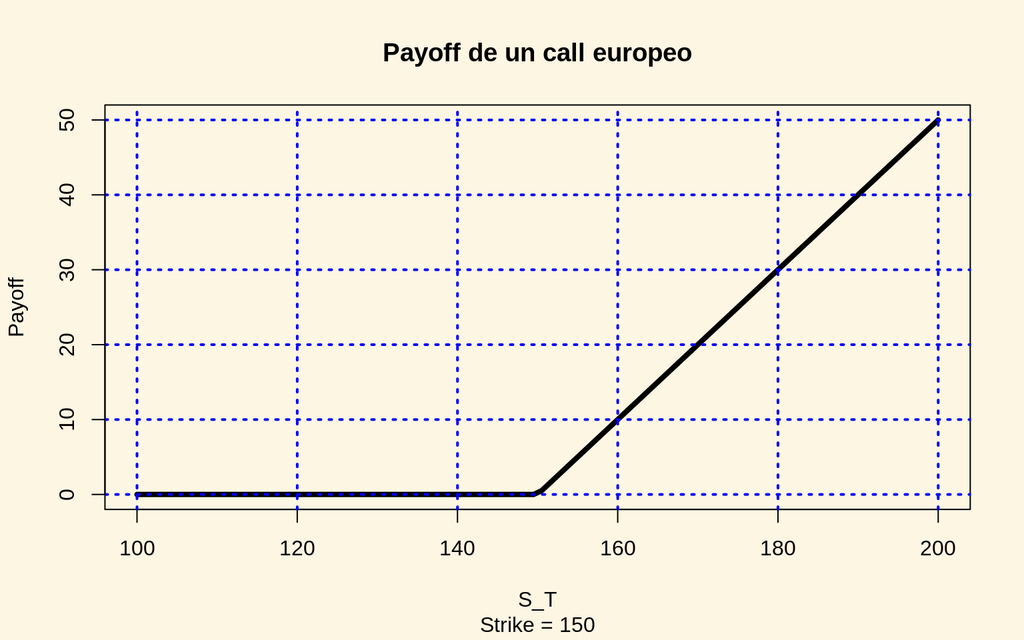

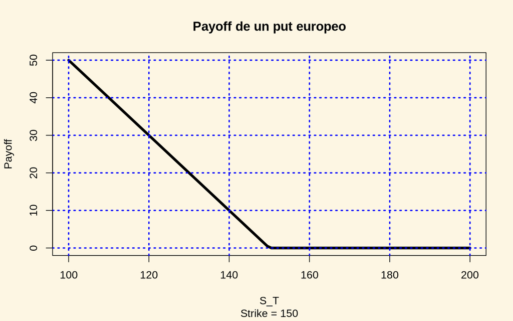

## **Movimiento browniano**

Un movimiento browniano (formalmente un proceso de Wiener) es un proceso estocástico $\{W\}_{t\geq 0}$ que satisface lo siguiente:

1. $W_0 = 0$.
2. El mapeo $t \rightarrow W_t$ es una función continua.
3. Los incrementos $\{W_{t_1} - W_{t_0}, W_{t_2} - W_{t_1}, \ldots, W_{t_k} - W_{t_{k-1}} \}$ son variables aleatorias independientes.
4. Para $s < t$, $W_t - W_s \sim N(0, \sigma^2 = t - s)$.

## **Modelo Black-Scholes-Merton**

En el modelo de Black-Scholes-Merton, se tiene un mercado en el cual existen únicamente tres instrumentos:

1. Acción $S$.
2. Cuenta de ahorro, $B_t$ que gana una tasa libre de riesgo $r$.

$$\dfrac{B_t}{B_t} = rdt \implies B_t = e^{rt}$$
3. Instrumento derivado $V$ cuyo subyacente es $S$.

El precio de la acción se modela utilizando un movimiento browniano geométrico

$$dS_t = rS_tdt + \sigma S_tdW_t$$

**Nota:**

Realmente esta es la dinámica que sigue $\{S_t\}_{t\geq 0}$ bajo una medidad de probabilidad, $\mathbb{Q}$, llamada medida neutral al riesgo.

## **Valuación de derivados**

Bajo ciertas condiciones, el precio en el tiempo $t$ de un producto financiero derivado con función de payoff $H$ y cuyo subyacente es $S$ está dado por:

$$Precio_H(S,t) = e^{-r(T-t)}E_{Q}[H(S,T)]$$

en donde $Q$ es la medida neutral al riesgo.

En particular para un call europeo

$$Call(S,K,t,T,r,\sigma) = e^{-r(T-t)}E_{Q}[\max(S_T - K, 0)]$$

## **Monte Carlo para valuar derivados**

1. Simula trayectorias del subyacente.
2. Para cada trayectoria calcula el payoff del derivado $H(S,T)$.
3. Aproxima $E_{Q}[H(S,T)]$ promediando el payoff de cada una de las trayectorias.
4. Aplica el factor de descuento apropiado, en este caso $e^{-r(T-t)}$, a la cantidad obtenida en el punto anterior.

## **Esquema de Euler para simular $S_t$**

Para simular el proceso dado por la ecuación diferencial estocástica

$$dS_t = rS_tdt + \sigma S_t dW_t$$

1. Crear una partición, $\Pi = \{t_0 = 0, t_1, \ldots, t_N = T \}$ del intervalo $[0, T]$ dividiéndolo en $N$ partes iguales (número de pasos) y haciendo $\Delta = \dfrac{\frac{T - t_0}{Y}}{N}$ en donde $Y$ es el número de días en el año.
2. Sustituir $dt$ por $\Delta$ y $dW_t$ por $\sqrt{\Delta}Z$ en donde $Z \sim N(0,1)$ (número aleatorio normal media cero desviación estándar 1)
3. Calcular los siguientes precios utilizando la discretización

$$S_{t_{i+1}} = S_{t_{i}} + r S_{t_{i}} \Delta + \sigma S_{t_{i}}\sqrt{\Delta}Z_{i+1}$$

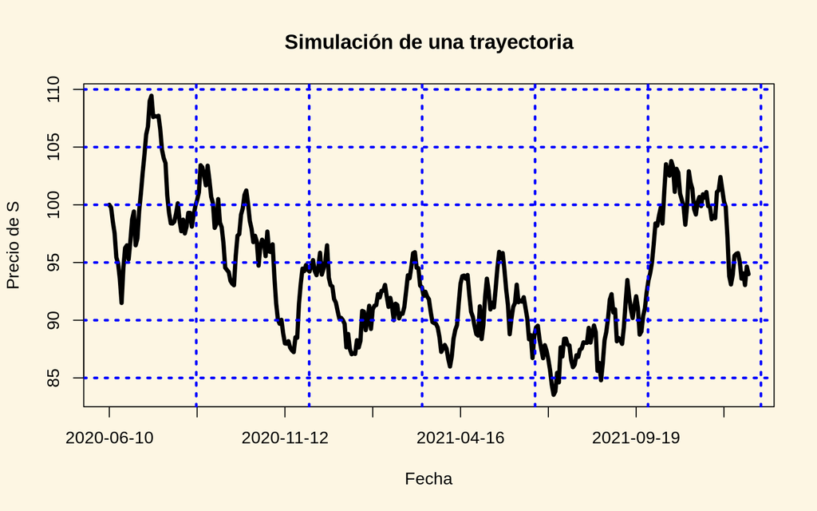

## **Fórmulas analíticas**

Bajo el modelo de Black-Scholes, el precio, en el tiempo $t$, de un call del tipo europeo está dado por

$$Call(S,K,t,T,r,\sigma) = S_t\mathbf{N}(d_1) - e^{-r(T-t)}K\mathbf{N}(d_2)$$

- $\mathbf{N}$ Es la **función de distribución acumulada** de una variable aleatoria $N(0,1)$.
- $d_1 = \dfrac{ \ln \dfrac{S_t}{K} + (r + 0.5\sigma^2) (T-t) }{\sigma \sqrt{T-t}}$
- $d_2 = \dfrac{ \ln \dfrac{S_t}{K} + (r - 0.5\sigma^2) (T-t) }{\sigma \sqrt{T-t}}$
- $T$ es la fecha de vencimiento.
- $t$ es la fecha de valuación.
- $T - t$ es el plazo para el vencimiento (**en fracción de años**).
- $r$ es la tasa libre de riesgo (continua anual)
- $\sigma$ volatilidad del subyacente.
- $K$ precio strike.

En el caso de un put, se tiene

$$Put(S,K,t,T,r,\sigma) = e^{-r(T-t)}K\mathbf{N}(-d_2) - S_t\mathbf{N}(-d_1)$$